# Movies_project

## 4. Eliminate mismatched rows

The dataframe was put together by merging two different sources of data and it is possible that the merging process was inaccurate in some cases (the merge was done based on movie title, but there are cases of different movies with the same title). There are 3 columns that contain date information: `Year` (numeric year), `Date` (numeric year), and `Released` (string representation of the release date).

Find and remove all rows where a merge error occurred based on a mismatch between these variables.

```r
# Remove rows with Year/Date/Released mismatch

# Parse the Released column
df2$Released_Year = sapply(1:nrow(df2), function(x) as.numeric(
  strsplit(as.character(df2$Released[x]),"-")[[1]][1]))

df2$Released_Month = sapply(1:nrow(df2), function(x) as.numeric(
  strsplit(as.character(df2$Released[x]),"-")[[1]][2]))

# Mismatch rows
mismatch_rows = sapply(1:nrow(df2), function(x)
  (df2$Year[x] != df2$Date[x] || df2$Year[x] != df2$Released_Year[x]))

# Do not remove the NA rows
mismatch_rows[is.na(mismatch_rows)] = FALSE

### Avoid removing more than 10% of the rows that have a `Gross` value present.
# Maximum rows with Gross present can be removed
Max_N_removal = round(sum(!is.na(df2$Gross)) * 0.1)

# Mismatch and Gross present rows
mismatch_gross_rows = sapply(1:nrow(df2),
                             function(x)
  mismatch_rows[x] && (!is.na(df2$Gross[x])))

set.seed(5)
if (sum(mismatch_gross_rows) > Max_N_removal) {
  # Random select some rows, and do not remove
  # them so that no more 10% rows with gross
  # present will not be removed
  keepRows = sample(which(mismatch_gross_rows %in% TRUE),
                    sum(mismatch_gross_rows) - Max_N_removal,
                    replace = FALSE)
  mismatch_rows[keepRows] = FALSE
}

# Select only matched rows
df2 = df2[!mismatch_rows,]
```

**Analysis**: Removal logic: 1) The Released column was parsed to retrieve the year; 2) Identify rows with mismatch between Year, Date, and Year(from Released); 3) Treat all NA as match; 4) Calculate the maximum number of rows with Gross present could be removed; 5) Identify and calculate the number of mismatch rows with Gross present; 6) If the number of step 5 is smaller than step 4, do nothing. Otherwise randomly sample n rows from step 5 and treat them as match(i.e., do not remove them). n is the difference between the numbers in step 4 and 5. There are 34587 rows remaining in the resulting dataframe.

## 5. Explore `Gross` revenue

For the commercial success of a movie, production houses want to maximize Gross revenue. Investigate if Gross revenue is related to Budget, Runtime or Genre in any way.

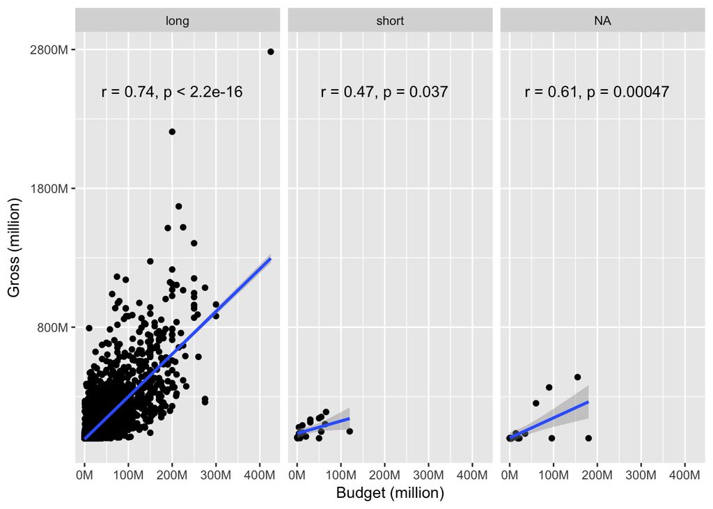

```r
# Investigate if Gross Revenue is related to Budget, Runtime or Genre

# Separate movie by runtime (less than 40mins --> short, otherwise long)
df2$Duration[df2$Runtime<40] = "short"
df2$Duration[df2$Runtime>=40] = "long"

# Gross vs. Budget/Runtime(short vs. long)
ggplot(data = df2, aes(x=Budget, y=Gross)) +
  geom_point(na.rm = TRUE) +
  geom_smooth(method=lm, na.rm = TRUE) +
  stat_cor(method = "pearson", label.x = 200000000,
           label.y = 2500000000, na.rm = TRUE) +
  facet_grid(. ~ Duration) +
  scale_x_continuous(breaks=seq(0, 450000000, 100000000),
                     labels = function(x){paste0(x/1000000, 'M')}) +
  scale_y_continuous(breaks=seq(-200000000, 3000000000, 1000000000),
                     labels = function(x){paste0(x/1000000, 'M')}) +
  labs(x = "Budget (million)", y = "Gross (million)")
```